# Wikia census: cleaning and analysis

# Integración

Ahora vamos a unir los dos datasets de los cuales disponemos: Wikia Census y Wikia page views. Es lo podemos hacer añadiendo los datos de visitas al dataframe `wikis` que ya tenemos. Para ello debemos juntar ambos dataframes usando como columna identificadora común la columna `url`.

```r
wikis_all = merge(wikis, wikis_pgv, by="url")
dim(wikis_all)
```

```
## [1] 266408     35
```

```r
summary(wikis_all)
```

```
##                                 url                     creation_date
##  http://0002oifos.wikia.com       :     1   2006-03-16 13:42:45:   370
##  http://001-game-creator.wikia.com:     1   2004-11-11 23:33:14:    77
##  http://001littlebighelp.wikia.com:     1   2017-10-16 21:02:01:    12
##  http://007fanon.wikia.com        :     1   2006-10-28 11:16:22:    11
##  http://007goldeneye.wikia.com    :     1   2017-10-02 21:37:50:     8
##  http://007-james-bond.wikia.com  :     1   2018-02-08 13:53:15:     7
##  (Other)                          :266402   (Other)            :265923
##                         domain       founding_user_id
##  cliff-side.wikia.com      :     2   Min.   :       0
##  0002oifos.wikia.com       :     1   1st Qu.: 4893531
##  001-game-creator.wikia.com:     1   Median :25311196
##  001littlebighelp.wikia.com:     1   Mean   :19946785
##  007fanon.wikia.com        :     1   3rd Qu.:32232648
##  007goldeneye.wikia.com    :     1   Max.   :36902116
##  (Other)                   :266401   NA's   :35
##                                     headline             hub
##                                         :258992   Games    :100378
##  Alice Wiki                             :     2   Lifestyle: 62942
##  Assassin's Creed Wiki                  :     2   TV       : 42839
##  Bakugan Wiki                           :     2   Books    : 21363
##  Bienvenidos a PokéMewtwo y PokéFantasy.:     2   Comics   : 13757
##  BioShock Wiki                          :     2   Movies   : 13436
##  (Other)                                :  7406   (Other)  : 11693
##        id               lang           language
##  Min.   :      1   en     :191596   en     :191596
##  1st Qu.: 643464   es     : 28618   es     : 28618
##  Median :1240829   ru     : 12298   ru     : 12298
##  Mean   :1121512   de     :  8741   de     :  8741
##  3rd Qu.:1668302   pl     :  7318   pl     :  7318
##  Max.   :1807291   fr     :  6558   fr     :  6558
##                    (Other): 11279   (Other): 11279
##                   name        stats.activeUsers   stats.admins
##  Test Wiki          :    60   Min.   :   0.000   Min.   :  0.000
##  Naruto Wiki        :    53   1st Qu.:   0.000   1st Qu.:  1.000
##  Harry Potter Wiki  :    46   Median :   0.000   Median :  1.000
##  Pokemon Wiki       :    46   Mean   :   0.813   Mean   :  1.483
##  Minecraft Wiki     :    42   3rd Qu.:   0.000   3rd Qu.:  1.000
##  Final Frontier Wiki:    39   Max.   :7311.000   Max.   :248.000
##  (Other)            :266122
```

[output cut: 49 more lines]

```
##  20:00, December 11, 2013 :   375   Min.   :1-07-28 20:25:00
##  09:37, September 25, 2006:   332   1st Qu.:2012-12-02 14:52:45
##  21:24, February 22, 2018 :   211   Median :2015-08-03 18:29:00
##  15:07, October 4, 2016   :   165   Mean   :2015-03-04 03:23:54
##  21:27 22 feb 2018        :    73   3rd Qu.:2017-12-27 03:25:15
##  22:19 29 mar 2017        :    67   Max.   :2018-09-17 19:34:00
##  (Other)                  :265185
##       age       visited_pages      total_views
##  Min.   : 112   Min.   :   0.00   Min.   :       0
##  1st Qu.: 377   1st Qu.:   0.00   1st Qu.:       0
##  Median :1253   Median :   0.00   Median :       0
##  Mean   :1403   Mean   :  12.47   Mean   :    2959
##  3rd Qu.:2227   3rd Qu.:   2.00   3rd Qu.:      15
##  Max.   :7523   Max.   :1000.00   Max.   :20386167
##
```

# Transformación

Definimos una wiki como inactiva cuando el número de usuarios activos en el último mes (atributo `stats.activeUsers`) es igual a cero. Esto nos resultará útil para el posterior paso de análisis.

Para ello, creamos una nueva columna llamada `active` que será TRUE si stats.activeUsers > 0 o FALSE en caso contrario.

```r
wikis_all$active = wikis_all$stats.activeUsers > 0
str(wikis_all$active)
```

```
##  logi [1:266408] FALSE FALSE FALSE TRUE FALSE FALSE ...
```

Similarmente, creamos una columna `visited` que será TRUE si ha habido alguna visita en el último mes en la wiki, o FALSE en caso contrario.

```r
wikis_all$visited = wikis_all$total_views > 0
str(wikis_all$visited)
```

```
##  logi [1:266408] FALSE TRUE FALSE TRUE TRUE TRUE ...
```

# Análisis

Un análisis que me resulta interesante es ver si hay correlación entre ciertas variables y la actividad/inactividad de las wikis.

Primero, vamos a ver si hay correlacción lineal entre el número de usuarios activos y el número de visitas en el último mes:

```r
regmodel <- lm( stats.activeUsers ~ total_views + visited_pages, data = wikis_all)
summary(regmodel)
```

```
##
## Call:
## lm(formula = stats.activeUsers ~ total_views + visited_pages,
##     data = wikis_all)
##
## Residuals:
##    Min     1Q Median     3Q    Max
## -969.8   -0.2   -0.2   -0.2 7273.8
##
## Coefficients:
##                Estimate Std. Error t value Pr(>|t|)
## (Intercept)   1.855e-01  3.498e-02   5.304 1.14e-07 ***
## total_views   4.712e-05  3.921e-07 120.175  < 2e-16 ***
## visited_pages 3.914e-02  5.044e-04  77.597  < 2e-16 ***
## ---
## Signif. codes:  0 '***' 0.001 '**' 0.01 '*' 0.05 '.' 0.1 ' ' 1
##
## Residual standard error: 17.79 on 266405 degrees of freedom
## Multiple R-squared:  0.1005, Adjusted R-squared:  0.1005
## F-statistic: 1.488e+04 on 2 and 266405 DF,  p-value: < 2.2e-16
```

Los resultados muestran que ambas variables: total_views y visited_pages son variables explicativas para determinar el número de usuarios activos.

```r
regmodel <- lm( total_views ~ stats.activeUsers, data = wikis_all)
summary(regmodel)
```

```
##
## Call:
## lm(formula = total_views ~ stats.activeUsers, data = wikis_all)
##
## Residuals:
##       Min        1Q    Median        3Q       Max
## -10144756     -1817     -1817     -1813  20342218
##
## Coefficients:
##                   Estimate Std. Error t value Pr(>|t|)
## (Intercept)       1817.006    173.014    10.5   <2e-16 ***
## stats.activeUsers 1404.409      9.217   152.4   <2e-16 ***
## ---
## Signif. codes:  0 '***' 0.001 '**' 0.01 '*' 0.05 '.' 0.1 ' ' 1
##
## Residual standard error: 89220 on 266406 degrees of freedom
## Multiple R-squared:  0.08016,    Adjusted R-squared:  0.08016
## F-statistic: 2.322e+04 on 1 and 266406 DF,  p-value: < 2.2e-16
```

A continuación, vamos a ver qué factores determinan que una wiki esté activa/inactiva. Usamos un modelo de regresión logística y seleccionamos un subconjunto de variables que nos resulten relevantes para este análisis:

```r
RELEVANT_ATTRS = c("hub", "language", "stats.articles", "stats.admins", "stats.edits", "stats.pages", "stats.pages", "users_1", "users_5", "users_10", "users_20", "users_50", "users_100")
formula <- as.formula(paste("active ~ ", paste(RELEVANT_ATTRS, collapse = "+") ))
regmodel.1 <- glm( formula = formula, family = binomial(link = 'logit'), data = wikis_all)
summary(regmodel.1)
```

```
##
## Call:
## glm(formula = formula, family = binomial(link = "logit"), data = wikis_all)
##
## Deviance Residuals:
##     Min       1Q   Median       3Q      Max
## -8.4904  -0.7120  -0.6713  -0.5095   5.8588
##
## Coefficients:
##                  Estimate Std. Error z value Pr(>|z|)
## (Intercept)    -1.323e+01  2.018e+02  -0.066   0.9477
## hubComics      -1.007e-01  2.518e-02  -4.000 6.34e-05 ***
## hubGames       -2.874e-01  1.742e-02 -16.496  < 2e-16 ***
## hubLifestyle   -6.746e-01  1.908e-02 -35.365  < 2e-16 ***
## hubMovies       5.162e-02  2.485e-02   2.078   0.0377 *
## hubMusic       -5.878e-02  2.939e-02  -2.000   0.0455 *
## hubOther       -2.620e+00  1.134e-01 -23.113  < 2e-16 ***
## hubTV          -3.226e-01  1.963e-02 -16.432  < 2e-16 ***
## languageaf      1.352e+01  2.018e+02   0.067   0.9466
## languageam      1.379e+01  2.018e+02   0.068   0.9455
## languagear      1.147e+01  2.018e+02   0.057   0.9547
## languageast    -2.761e-01  5.722e+02   0.000   0.9996
## languageaz      1.306e+01  2.018e+02   0.065   0.9484
## languagebe      1.250e+01  2.018e+02   0.062   0.9506
## languagebg      1.182e+01  2.018e+02   0.059   0.9533
## languagebn      1.224e+01  2.018e+02   0.061   0.9516
## languagebs      1.221e+01  2.018e+02   0.061   0.9517
## languagebxr     1.477e+01  2.018e+02   0.073   0.9417
## languageca      1.177e+01  2.018e+02   0.058   0.9535
## languagecho     2.739e+01  5.722e+02   0.048   0.9618
## languagecs      1.173e+01  2.018e+02   0.058   0.9536
## languagecy      1.337e+01  2.018e+02   0.066   0.9472
## languagecz     -4.954e-01  5.722e+02  -0.001   0.9993
## languageda      1.151e+01  2.018e+02   0.057   0.9545
## languagede      1.172e+01  2.018e+02   0.058   0.9537
## languageel      1.131e+01  2.018e+02   0.056   0.9553
## languageen      1.215e+01  2.018e+02   0.060   0.9520
## languageeo      1.306e+01  2.018e+02   0.065   0.9484
## languagees      1.188e+01  2.018e+02   0.059   0.9530
## languageeu      6.689e-02  2.959e+02   0.000   0.9998
```

[output cut: 60 more lines]

```
## users_5        -2.163e-02  3.206e-03  -6.749 1.49e-11 ***
## users_10       -2.216e-03  5.323e-03  -0.416   0.6772
## users_20       -8.592e-03  5.933e-03  -1.448   0.1476
## users_50       -1.520e-02  7.532e-03  -2.018   0.0435 *
## users_100       1.056e-01  7.120e-03  14.833  < 2e-16 ***
## ---
## Signif. codes:  0 '***' 0.001 '**' 0.01 '*' 0.05 '.' 0.1 ' ' 1
##
## (Dispersion parameter for binomial family taken to be 1)
##
##     Null deviance: 282008  on 266407  degrees of freedom
## Residual deviance: 269750  on 266313  degrees of freedom
## AIC: 269940
##
## Number of Fisher Scoring iterations: 12
```

Los atributos que influyen a la hora de determinar que la wiki esté activa o no, son (sin ordenar por importancia): hubComics, hubGames, hubLifestyle, hubMovies, hubOther, hubTV, stats.articles, stats.admins, stats.edits, stats.pages, users_1, users_5, users_50 y users_100.

hubMusic y users_20 influyen muy poco, así que consideraremos que no son relevantes para nuestro modelo.

Observamos que el idioma en el que esté la wiki no es relevante para determinar que esté activa o no.

Ordenamos los atributos por importancia:

```r
idx <- order(coef(summary(regmodel.1))[,4])  # sort out the p-values
out <- coef(summary(regmodel.1))[idx,]       # reorder coef, SE, etc. by increasing p
print(xtable(out, caption = "Atributos relevantes para que una wiki esté activa", auto = TRUE))
```

```
## % latex table generated in R 3.4.4 by xtable 1.8-3 package
## % Tue Jan  8 10:46:29 2019
## \begin{table}[ht]
## \centering
## \begin{tabular}{lrrrr}
##   \hline
##  & Estimate & Std. Error & z value & Pr($>$$|$z$|$) \\
##   \hline
## hubLifestyle & -0.6745896 & 0.0190751 & -35.3649966 & 0.0000000 \\
##   users\_1 & 0.0132432 & 0.0005612 & 23.5973179 & 0.0000000 \\
##   hubOther & -2.6201704 & 0.1133654 & -23.1126146 & 0.0000000 \\
##   hubGames & -0.2874306 & 0.0174244 & -16.4958355 & 0.0000000 \\
##   hubTV & -0.3226256 & 0.0196344 & -16.4316569 & 0.0000000 \\
##   users\_100 & 0.1056071 & 0.0071197 & 14.8331689 & 0.0000000 \\
##   stats.pages & -0.0000590 & 0.0000041 & -14.4427094 & 0.0000000 \\
##   stats.admins & 0.0397204 & 0.0034561 & 11.4926831 & 0.0000000 \\
##   stats.articles & 0.0001077 & 0.0000107 & 10.0578601 & 0.0000000 \\
##   stats.edits & 0.0000151 & 0.0000021 & 7.3118309 & 0.0000000 \\
##   users\_5 & -0.0216335 & 0.0032057 & -6.7485648 & 0.0000000 \\
##   hubComics & -0.1007007 & 0.0251762 & -3.9998421 & 0.0000634 \\
##   hubMovies & 0.0516201 & 0.0248464 & 2.0775673 & 0.0377492 \\
##   users\_50 & -0.0152032 & 0.0075322 & -2.0184275 & 0.0435468 \\
##   hubMusic & -0.0587823 & 0.0293918 & -1.9999564 & 0.0455050 \\
##   users\_20 & -0.0085916 & 0.0059331 & -1.4480781 & 0.1475952 \\
##   users\_10 & -0.0022160 & 0.0053233 & -0.4162842 & 0.6772020 \\
##   languagebxr & 14.7673942 & 201.7725273 & 0.0731883 & 0.9416563 \\
##   languageam & 13.7872590 & 201.7712531 & 0.0683311 & 0.9455220 \\
##   languagerm & 13.7680203 & 201.7712610 & 0.0682358 & 0.9455979 \\
##   languageaf & 13.5222399 & 201.7665146 & 0.0670192 & 0.9465664 \\
##   languagecy & 13.3705066 & 201.7675377 & 0.0662669 & 0.9471653 \\
##   languagegsw & 13.2619398 & 201.7712987 & 0.0657276 & 0.9475947 \\
##   (Intercept) & -13.2307208 & 201.7662952 & -0.0655745 & 0.9477166 \\
##   languageeo & 13.0594316 & 201.7666595 & 0.0647254 & 0.9483926 \\
##   languageaz & 13.0582164 & 201.7676396 & 0.0647191 & 0.9483977 \\
##   languagehi & 12.8209650 & 201.7670591 & 0.0635434 & 0.9493338 \\
##   languagekn & 12.7807584 & 201.7700650 & 0.0633432 & 0.9494932 \\
##   languagesr & 12.6197157 & 201.7665065 & 0.0625461 & 0.9501279 \\
##   languagehy & 12.5885347 & 201.7680442 & 0.0623911 & 0.9502514 \\
##   languagems & 12.5818488 & 201.7665552 & 0.0623584 & 0.9502774 \\
##   languagebe & 12.4953894 & 201.7670046 & 0.0619298 & 0.9506187 \\
```

[output cut: 52 more lines]

```
##   languagept-br & 0.1956765 & 572.1667213 & 0.0003420 & 0.9997271 \\
##   languagemr & -0.1223277 & 424.7265492 & -0.0002880 & 0.9997702 \\
##   languagepag & 0.1555978 & 572.1667214 & 0.0002719 & 0.9997830 \\
##   languageeu & 0.0668850 & 295.8625382 & 0.0002261 & 0.9998196 \\
##   languagegu & 0.1086797 & 572.1667215 & 0.0001899 & 0.9998484 \\
##   languagemn & -0.0548507 & 296.3766479 & -0.0001851 & 0.9998523 \\
##   languagesco & -0.0811700 & 572.1667214 & -0.0001419 & 0.9998868 \\
##   languagekr & -0.0779091 & 572.1667213 & -0.0001362 & 0.9998914 \\
##   languageksh & 0.0638889 & 572.1667214 & 0.0001117 & 0.9999109 \\
##   languageml & -0.0337020 & 332.8981733 & -0.0001012 & 0.9999192 \\
##   languagepie & 0.0009667 & 572.1667215 & 0.0000017 & 0.9999987 \\
##    \hline
## \end{tabular}
## \caption{Atributos relevantes para que una wiki esté activa}
## \end{table}
```

Respecto a los hubs, según este modelo “todos”, aunque los hubs de Movies y Music lo son en menor nivel, son algo relevantes para determinar la actividad o no de la wiki. Esto es como no decir nada puesto que si cualquier hub es relevante y toda wiki pertenece a uno y a un solo hub, nunca podemos distinguir cuando es un hecho relevante y cuando no.

Dicho todo lo anterior, observamos que los cinco atributos más importantes son:

1. users_1: El número de usuarios o editores de la wiki con al menos una edición es un estimador positivo.
2. users_100: El número de usuarios o editores de la wiki con al menos cien ediciones es un estimador positivo.
3. stats.pages: El número de páginas de la wiki es un estimador negativo.
4. stats.admins: El número de usuarios administradores es un estimador positivo.
5. stats.articles: El número de páginas de la wiki es un estimador positivo.

## Modelo de predicción para wikis visitadas

Repetimos el análisis pero ahora usando como indicador de actividad que la wiki haya tenido alguna visita en el último mes:

```r
formula <- as.formula(paste("visited ~ ", paste(RELEVANT_ATTRS, collapse = "+") ))
regmodel.2 <- glm( formula = formula, family = binomial(link = 'logit'), data = wikis_all)
summary(regmodel.2)
```

```
##
## Call:
## glm(formula = formula, family = binomial(link = "logit"), data = wikis_all)
##
## Deviance Residuals:
##     Min       1Q   Median       3Q      Max
## -8.4904  -0.8993  -0.7436   1.1382   4.5640
##
## Coefficients:
##                  Estimate Std. Error z value Pr(>|z|)
## (Intercept)    -1.458e+01  3.322e+02  -0.044   0.9650
## hubComics       2.782e-01  2.425e-02  11.473  < 2e-16 ***
## hubGames        4.102e-02  1.684e-02   2.436   0.0149 *
## hubLifestyle   -2.021e-01  1.770e-02 -11.420  < 2e-16 ***
## hubMovies       3.329e-01  2.419e-02  13.760  < 2e-16 ***
## hubMusic        2.112e-01  2.801e-02   7.539 4.75e-14 ***
## hubOther       -1.471e+00  5.877e-02 -25.021  < 2e-16 ***
## hubTV           2.840e-01  1.866e-02  15.224  < 2e-16 ***
## languageaf      1.479e+01  3.322e+02   0.045   0.9645
## languageam      2.833e+01  7.011e+02   0.040   0.9678
## languagear      1.451e+01  3.322e+02   0.044   0.9652
## languageast     2.139e+01  9.432e+02   0.023   0.9819
## languageaz      1.246e+01  3.322e+02   0.037   0.9701
## languagebe      1.444e+01  3.322e+02   0.043   0.9653
## languagebg      1.451e+01  3.322e+02   0.044   0.9652
## languagebn      1.415e+01  3.322e+02   0.043   0.9660
## languagebs      1.278e+01  3.322e+02   0.038   0.9693
## languagebxr     1.507e+01  3.322e+02   0.045   0.9638
## languageca      1.367e+01  3.322e+02   0.041   0.9672
## languagecho     2.773e-01  9.432e+02   0.000   0.9998
## languagecs      1.349e+01  3.322e+02   0.041   0.9676
## languagecy      1.500e+01  3.322e+02   0.045   0.9640
## languagecz      2.723e+01  9.432e+02   0.029   0.9770
## languageda      1.452e+01  3.322e+02   0.044   0.9651
## languagede      1.400e+01  3.322e+02   0.042   0.9664
## languageel      1.342e+01  3.322e+02   0.040   0.9678
## languageen      1.351e+01  3.322e+02   0.041   0.9676
## languageeo      1.413e+01  3.322e+02   0.043   0.9661
## languagees      1.348e+01  3.322e+02   0.041   0.9676
## languageeu      1.341e+01  3.322e+02   0.040   0.9678
```

[output cut: 60 more lines]

```
## users_5         1.126e-01  5.103e-03  22.059  < 2e-16 ***
## users_10       -2.239e-02  7.311e-03  -3.062   0.0022 **
## users_20       -1.948e-02  8.072e-03  -2.413   0.0158 *
## users_50        4.530e-02  9.937e-03   4.558 5.16e-06 ***
## users_100       3.074e-01  1.114e-02  27.600  < 2e-16 ***
## ---
## Signif. codes:  0 '***' 0.001 '**' 0.01 '*' 0.05 '.' 0.1 ' ' 1
##
## (Dispersion parameter for binomial family taken to be 1)
##
##     Null deviance: 364973  on 266407  degrees of freedom
## Residual deviance: 306559  on 266313  degrees of freedom
## AIC: 306749
##
## Number of Fisher Scoring iterations: 13
```

Los resultados son muy parecidos a los obtenidos anteriormente para la variable active. Las diferencias son: 1) los valores de users_10 y users_20 cobran mayor importancia que en el modelo anterior, aunque siguen siendo menos importantes que los demás que ya señalamos como relevantes (users_1, users_5, users_50 y users_100); 2) el atributo stats.pages no es demasiado relevante.

Con estos resultados y sabiendo que una regresión lineal entre que una wiki esté visitada y esté activa, podemos confirmar que los factores para que una wiki se mantenga activa o para que sea visitada son los mismos, y son los que ya mencionamos en la tabla del apartado anterior.

# Visualización

Vamos a visualizar la correspondencia que acabamos de comentar entre visitas a las wikis y usuarios activos, mediante la llamada recta de regresión:

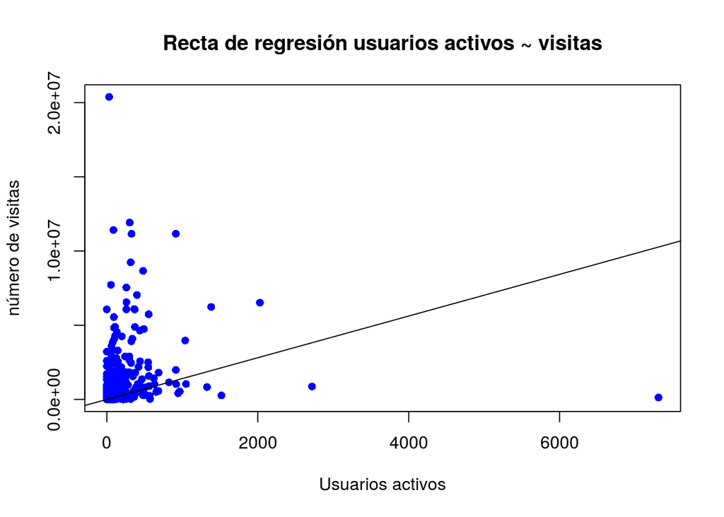

```r
plot(y = wikis_all$total_views, x = wikis_all$stats.activeUsers, type="p",  col = "blue", main="Recta de regresión usuarios activos ~ visitas", xlab = "Usuarios activos", ylab = "número de visitas", pch = 16)
abline(regmodel)
```

Vemos que la correlación se cumple en general, aunque hay algún *outlayer*. En particular, tenemos una wiki con muchos usuarios activos (la que más usuarios activos tiene) pero con apenas visitas y otra wiki con muchas visitas y apenas usuarios activos (la que más visitas tiene).

Vamos a ver de qué casos tan excepcionales se trata para entender el fenómeno mejor:

```r
# wiki con mayor número de visitas:
outlayer1 = head(wikis_all[with(wikis_all, order(desc(wikis_all$total_views))), c("url", "total_views", "stats.activeUsers", "users_1", "stats.pages", "stats.articles")], n = 1)
outlayer1
```

```
##                                        url total_views stats.activeUsers
## 163243 http://oldschoolrunescape.wikia.com    20386167                30
##        users_1 stats.pages stats.articles
## 163243   12134      101550          19769
```

La wiki en cuestión se llama: “http://oldschoolrunescape.wikia.com”, tiene 20386167 visitas en el último mes pero solamente 30 usuarios activos. Además tiene una gran cantidad de contenido y una sólida base de usuarios.

[Investigando un poco](https://en.wikipedia.org/wiki/Old_School_RuneScape), se trata de un videojuego de tipo MMORPG. La razón para que sea un caso aislado posiblemente sea que el 30 de Octubre de 2018 se lanzó una nueva versión del videojuego para Android, justo entre medias desde que se tomaron los datos estadísticos en cuanto a cantidad de usuarios: 19 de Octubre (fichero `20181019-wikia_stats_users_birthdate.csv`); a cuando se tomaron os datos de visitas a las wikis: 13 de noviembre (fichero `20181113_wikia-page-views.csv`).

Posiblemente, la misma causa sea válida para el caso aislado de una wiki con muchos usuarios activos y pocas visitas. Aún así, vamos a mirarla más de cerca:

```r
# wiki con mayor número de usuarios activos:
outlayer2 = head(wikis_all[with(wikis_all, order(desc(wikis_all$stats.activeUsers))), c("url", "total_views", "stats.activeUsers", "users_1", "stats.pages", "stats.articles")], n = 1)
outlayer2
```

```
##                              url total_views stats.activeUsers users_1
## 31678 http://community.wikia.com      124695              7311  127087
##       stats.pages stats.articles
## 31678     1158857          22511
```

“http://community.wikia.com” es una wiki especial, puesto que se trata de la wiki que tiene Wikia para publicar su propio contenido. Es una especia de *metawiki* de Wikia. Efectivamente, lo más seguro es que pase igual que con el caso anterior y haya un desajuste entre algo que hizo que la gente estuviese visitando la wiki a principios de noviembre del pasado año, pero que sin embargo en octubre no se diese tal evento.

# Repetición de análisis sin outlayers

Repetimos el análisis realizado previamente sin los recién localizados outlayers para ver si podemos extraer las mismas conclusiones:

```r
wikis_no_outlayers = subset(wikis_all, url != outlayer1$url & url != outlayer2$url)
dim(wikis_no_outlayers) # deberíamos haber pasado de 266408 wikis a 266406
```

```
## [1] 266406     37
```

```r
formula <- as.formula(paste("active ~ ", paste(RELEVANT_ATTRS, collapse = "+") ))
regmodel.3 <- glm( formula = formula, family = binomial(link = 'logit'), data = wikis_no_outlayers)
idx <- order(coef(summary(regmodel.3))[,4])  # sort out the p-values
out <- coef(summary(regmodel.3))[idx,]       # reorder coef, SE, etc. by increasing p
print(xtable(out, caption = "Atributos relevantes para que una wiki esté activa (sin outlayers)", auto = TRUE))
```

```
## % latex table generated in R 3.4.4 by xtable 1.8-3 package
## % Tue Jan  8 10:49:24 2019
## \begin{table}[ht]
## \centering
## \begin{tabular}{lrrrr}
##   \hline
##  & Estimate & Std. Error & z value & Pr($>$$|$z$|$) \\
##   \hline
## hubLifestyle & -0.6745896 & 0.0190751 & -35.3649999 & 0.0000000 \\
##   users\_1 & 0.0132434 & 0.0005612 & 23.5975614 & 0.0000000 \\
##   hubOther & -2.6201703 & 0.1133654 & -23.1126126 & 0.0000000 \\
##   hubGames & -0.2874305 & 0.0174244 & -16.4958331 & 0.0000000 \\
##   hubTV & -0.3226257 & 0.0196344 & -16.4316640 & 0.0000000 \\
##   users\_100 & 0.1056074 & 0.0071197 & 14.8331896 & 0.0000000 \\
##   stats.pages & -0.0000590 & 0.0000041 & -14.4426017 & 0.0000000 \\
##   stats.admins & 0.0397205 & 0.0034561 & 11.4927138 & 0.0000000 \\
##   stats.articles & 0.0001077 & 0.0000107 & 10.0580334 & 0.0000000 \\
##   stats.edits & 0.0000151 & 0.0000021 & 7.3116736 & 0.0000000 \\
##   users\_5 & -0.0216332 & 0.0032057 & -6.7484672 & 0.0000000 \\
##   hubComics & -0.1007008 & 0.0251762 & -3.9998456 & 0.0000634 \\
##   hubMovies & 0.0516200 & 0.0248464 & 2.0775633 & 0.0377496 \\
##   users\_50 & -0.0152032 & 0.0075322 & -2.0184349 & 0.0435460 \\
##   hubMusic & -0.0587824 & 0.0293918 & -1.9999589 & 0.0455047 \\
##   users\_20 & -0.0085925 & 0.0059331 & -1.4482290 & 0.1475530 \\
##   users\_10 & -0.0022162 & 0.0053233 & -0.4163312 & 0.6771677 \\
##   languagebxr & 11.7672757 & 45.0469597 & 0.2612224 & 0.7939210 \\
##   languageam & 10.7871412 & 45.0412520 & 0.2394947 & 0.8107220 \\
##   languagerm & 10.7679036 & 45.0412871 & 0.2390674 & 0.8110533 \\
##   languageaf & 10.5221227 & 45.0200199 & 0.2337210 & 0.8152016 \\
##   languagecy & 10.3703894 & 45.0246050 & 0.2303272 & 0.8178376 \\
##   languagegsw & 10.2618219 & 45.0414561 & 0.2278306 & 0.8197779 \\
##   (Intercept) & -10.2306036 & 45.0190366 & -0.2272506 & 0.8202289 \\
##   languageeo & 10.0593140 & 45.0206694 & 0.2234377 & 0.8231949 \\
##   languageaz & 10.0580995 & 45.0250615 & 0.2233889 & 0.8232328 \\
##   languagehi & 9.8208477 & 45.0224602 & 0.2181322 & 0.8273261 \\
##   languagekn & 9.7806410 & 45.0359291 & 0.2171742 & 0.8280726 \\
##   languagesr & 9.6195983 & 45.0199839 & 0.2136740 & 0.8308013 \\
##   languagehy & 9.5884172 & 45.0268749 & 0.2129488 & 0.8313669 \\
##   languagems & 9.5817314 & 45.0202022 & 0.2128318 & 0.8314581 \\
##   languagebe & 9.4952721 & 45.0222159 & 0.2109019 & 0.8329638 \\
```

[output cut: 52 more lines]

```
##   languagept-br & 0.1955982 & 127.6688162 & 0.0015321 & 0.9987776 \\
##   languagemr & -0.1228867 & 94.7876948 & -0.0012964 & 0.9989656 \\
##   languagepag & 0.1555180 & 127.6688163 & 0.0012181 & 0.9990281 \\
##   languageeu & 0.0668451 & 66.0150673 & 0.0010126 & 0.9991921 \\
##   languagegu & 0.1085998 & 127.6688167 & 0.0008506 & 0.9993213 \\
##   languagemn & -0.0555250 & 66.1409216 & -0.0008395 & 0.9993302 \\
##   languagesco & -0.0812489 & 127.6688165 & -0.0006364 & 0.9994922 \\
##   languagekr & -0.0779872 & 127.6688159 & -0.0006109 & 0.9995126 \\
##   languageksh & 0.0638095 & 127.6688165 & 0.0004998 & 0.9996012 \\
##   languageml & -0.0336905 & 74.2776847 & -0.0004536 & 0.9996381 \\
##   languagepie & 0.0008862 & 127.6688168 & 0.0000069 & 0.9999945 \\
##    \hline
## \end{tabular}
## \caption{Atributos relevantes para que una wiki esté activa (sin outlayers)}
## \end{table}
```

Como podemos comprobar, los resultados no han sido alterados al quitar los casos extremos. Posiblemente la tendencia sea muy predominante y tales wikis, muy populares y populares como hemos visto, compartan los mismos rasgos que hacen que la wiki esté activa.

# Conclusiones

Las wikis son un ecosistema de colaboración afianzado donde podemos estudiar fenómenos sociales de trabajo colaborativo interesantes. Además, disponemos de un dataset muy grande y variado de wikis con una gran cantidad de datos sobre el que podemos hacer un análisis extensivo y sacar conclusiones robustas.

Una de las características que podemos estudiar es qué factores son determinantes para que una comunidad online se mantenga activa, esto significa en el caso de las wikis, que haya usuarios activos editando la wiki. En nuestros análisis hemos descubierto que, para lograr dicho objetivo, los factores más relevantes son:

1. Que haya una base de usuarios registrados (users_1)
2. Que la wiki tenga usuarios asiduos y con experiencia (users_100)
3. Que la wiki tenga pocas páginas (stats.pages). El estimador es negativo, por tanto la relación es inversa.
4. Que la wiki tenga muchos administradores (stats.admins)
5. Que la wiki tenga páginas de contenido (stats.articles)

Además, también hemos corrobado que las visitas a una wiki (un indicador del interés o utilidad que tiene un recurso en internet) está correlacionada con el hecho de que tengan actividad (al menos un usuario activo en el último mes). Por tanto, los factores nombrados en el párrafo anterior son igualmente lo más relevantes para que una wiki sea visitada.

Por último, como hemos podido observar en el caso de la correlación entre visitas a las wikis y número de usuarios activos, quiero resaltar la importancia de que los datos estén actualizados y sincronizados en la misma fecha, porque de otra manera los análisis, visualizaciones y conclusiones que hagamos pueden ser engañosas o poco fiables.

A pesar de lo anterior, hemos confirmado que para nuestras conclusiones no nos afecta demasiado estos casos extremos “desincronizados”, puesto que para la inmensa mayoría de instancias de wikis en nuestro dataset la situación es bastante estable. Con esto quiero decir que las wikis “exitosas” (activas y con interés), que han conseguido reunir un equilibrio armonioso entre los factores nombrados anteriormente, lo son por varios meses seguidos; y, del mismo modo, las wikis abandonadas o sin interés llevan tiempo en la misma situación y el declive suele ser de forma paulatina.

# Salvado de nuevos datos

Finalmente, vamos a producir un fichero con los datos ya limpios, transformados e integrados, y con los nuevos campos que hemos añadido para el análisis:

```r
write.csv(wikis_all, "output_data/20190102-wikia_census_and_page_views-clean.csv")
```

# Referencias

Jimenez-Diaz, Guillermo, Abel Serrano, y Javier Arroyo. 2018. «A Wikia Census: Motives, Tools and Insights». En *Proceedings of the 14th International Symposium on Open Collaboration*, 2:1-2:6. OpenSym ’18. New York, NY, USA: ACM. doi:10.1145/3233391.3233526.